# Reproducible research and open tools for future-proof transport planning

Mobile Tartu 2024

Robin Lovelace

r.lovelace@leeds.ac.uk

University of Leeds, Active Travel England

June 10, 2024

# Introduction

## About me and my work

- Associate Professor of Transport Data Science
- Work with government
- Focus on impact
- Software developer and data scientist
- New methods for more reproducible, data-driven and participatory transport planning

[figure not shown]

[figure not shown]

[figure not shown]

## Contents

- Definitions: what is reproducible research and future proof transport planning?
- Reproducible research and open tools
- Future-proof transport planning

## Definitions

> a tool is a … piece of software or online service; a model … is method or process that is expounded in theoretical terms; software is … instructions that underlies digital tools Lovelace (2021)

**Reproducible research**: Other people can re-generate your results

**Open source software**: Software that is free to use and modify

**Open access tools**: Web applications for transport planning that are based on open source software, that anyone can use

**Open access data**: Data that is freely available to use and share

**Future-proof** work that is likely to be useful in the medium-term future

## Reproducibility

Reproducibility is a continuous variable (Peng 2011)

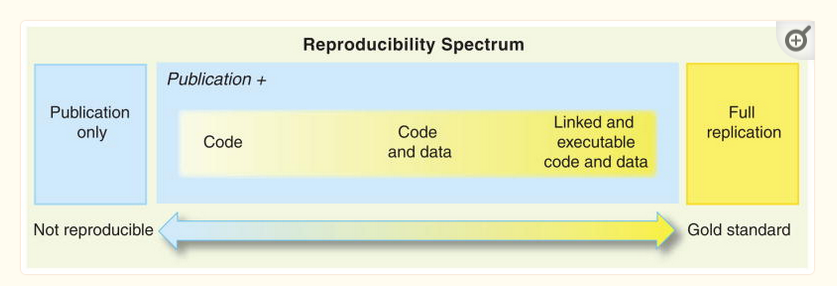

# Reproducible research

## Why make your research (more) reproducible?

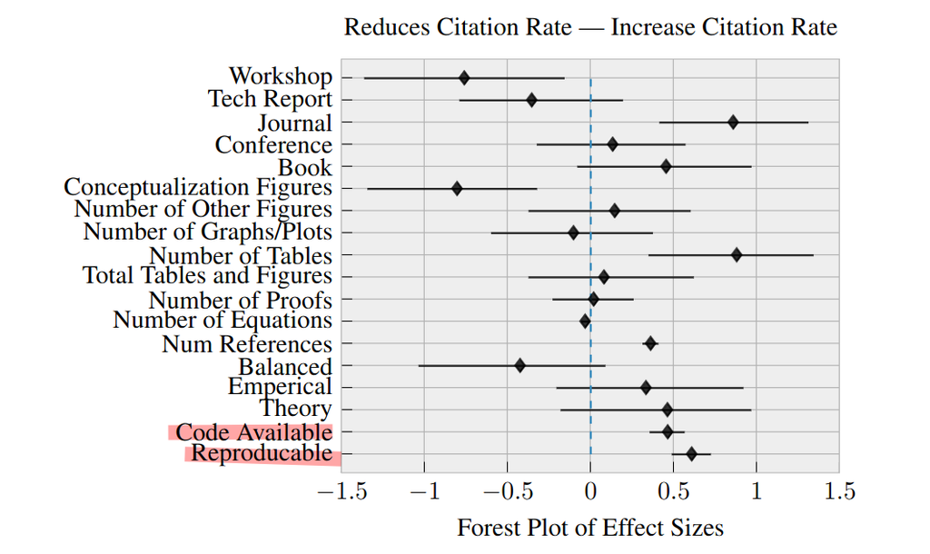

Source: Raff (2023)

- Scientific rigour
- Benefits to your future self
- Benefits to others
- Huge increase in potential for impact

## Why *not* make your research reproducible?

[figure not shown]

- Time
- Know-how
- Lack of permission
- Software is not open
- Data is not open access
- Someone might use it in unethical ways
- Someone might “steal” the work

## Example of fully reproducible research

[figure not shown]

Lovelace, Tennekes, and Carlino (2022)

## Reproducibility and generalisability

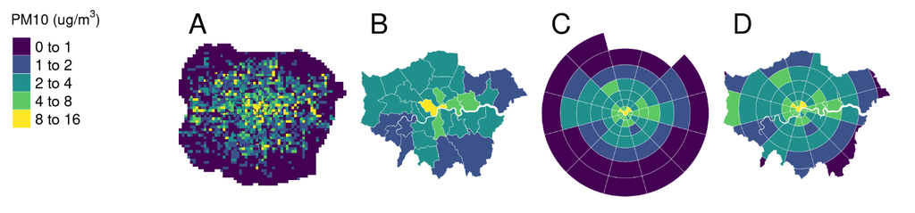

Illustration of the ClockBoard zoning system used to visualize a geographically dependendent phenomena: air quality, measured in mass of PM10 particles, measured in micrograms per cubic meter, from the London Atmospheric Emissions Inventory (LAEI). The facets show the data in spatial grid available from the LAEI, facet Am and aggregated to London boroughs B, to ClockBoard zones covering all the input data shown in C, and ClockBoard zones clipped by the administrative boundary of Greater London in D.

## Application: road traffic casualties

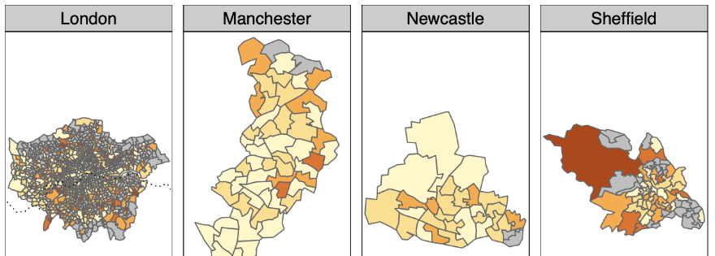

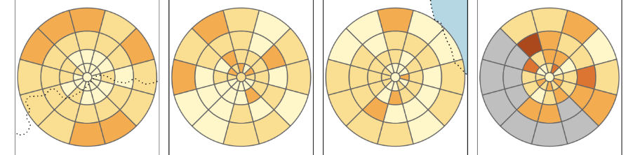

## International comparisons

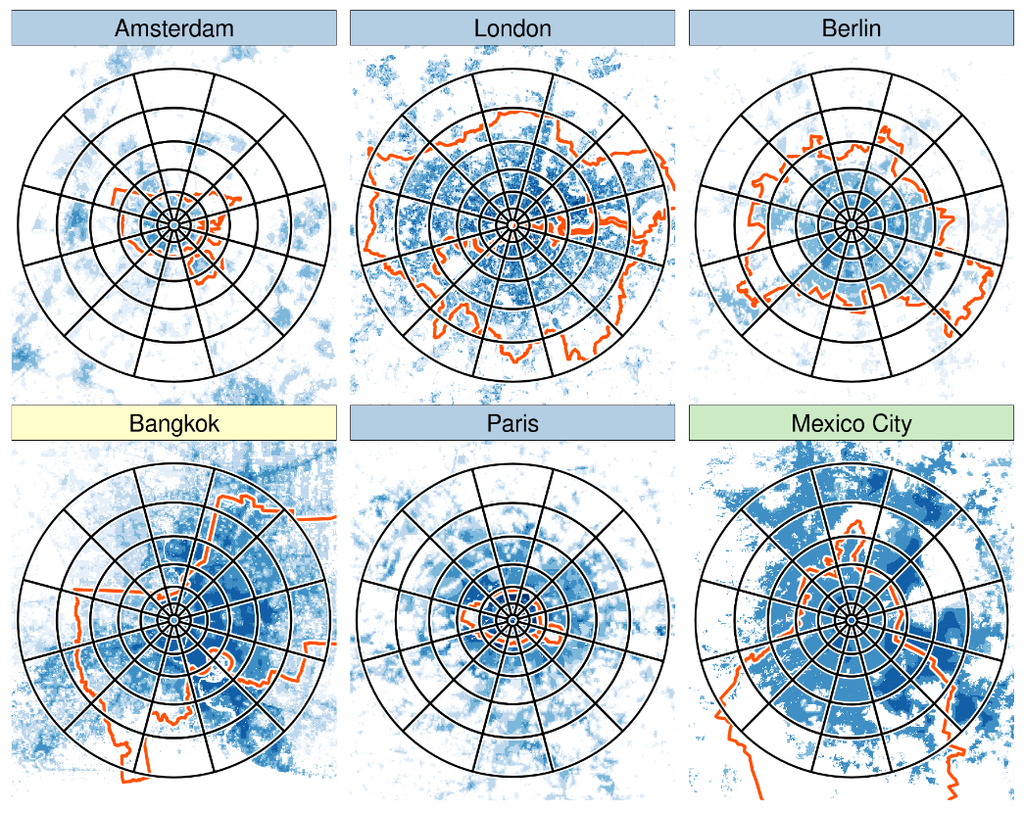

**Premise**: A key reason for reproducibility is *generalisability*.

# Open source software and open access tools

# Future-proof transport planning

## Drivers of demand for transport planning

transport planning software was originally designed in the late 1950s and onwards to plan for

> increased use of cars [for personal travel], and trucks for deliveries and goods movement Boyce and Williams (2015)

Thankfully that is no longer a priority:

> Policy drivers have changed dramatically since then: climate change mitigation, air quality improvement and public health are prioritised in the emergent ‘sustainable mobility paradigm’ Lovelace (2021)

How could/should/will demand shift in the future?

## AI takeover?

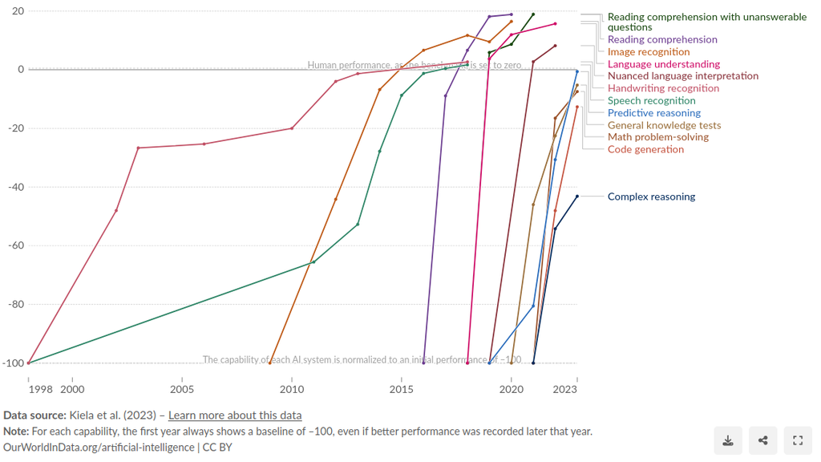

## Where are we headed with AI?

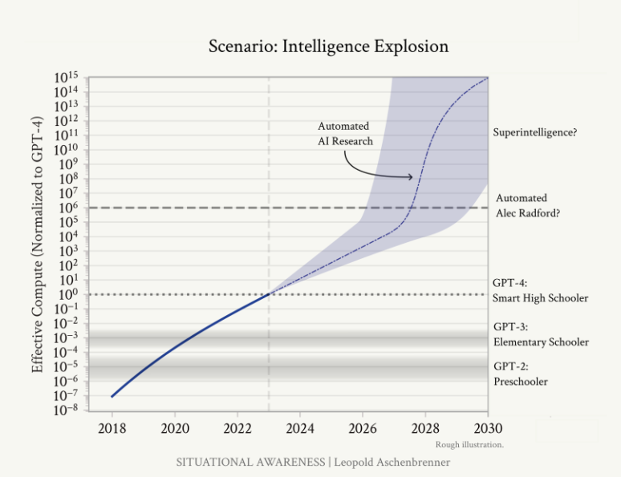

Source: https://situational-awareness.ai

## The limits of AI

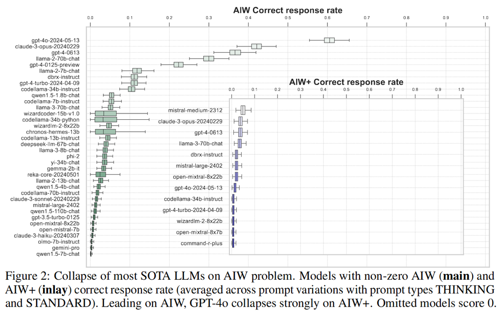

(Nezhurina et al., n.d.)

## Environmental costs of ‘AI’

[figure not shown]

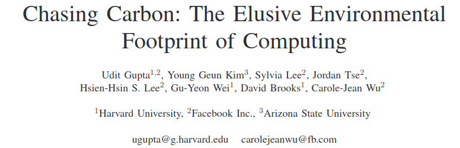

IT sector was already poised to become a decarbonisation bottleneck

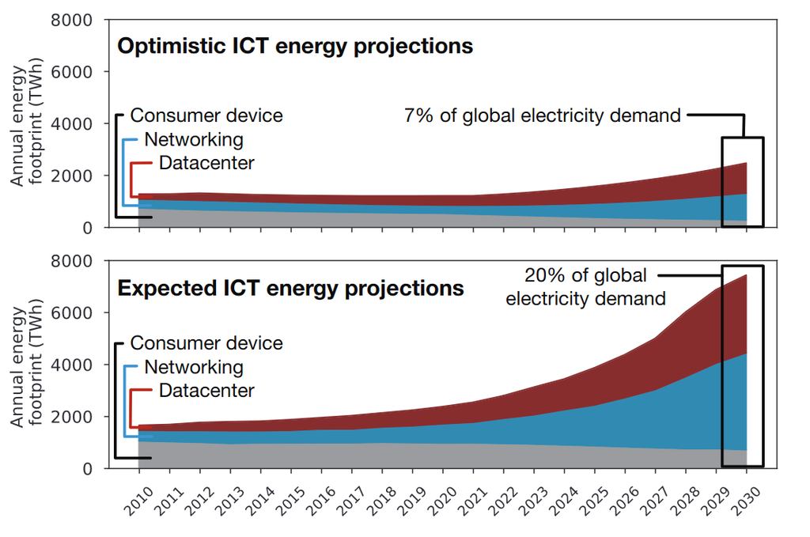

Source: [theregister.com](https://www.theregister.com/2024/05/16/microsoft_co2_emissions/) and Gupta et al. (2021)

## Factoring-in build-out of AI data centres

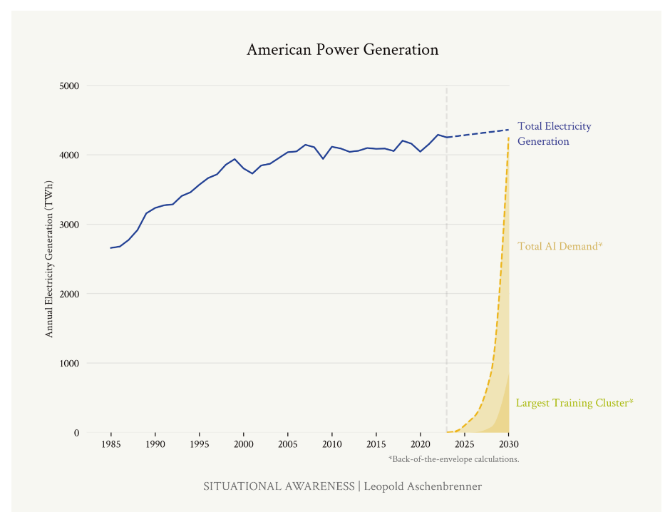

## Conclusions

- Reproducible research is a key part of future-proofing transport planning, for your work, and for the discipline as a whole
- Open source software and open access tools are key to this, especially if you want to have humans in the loop
- AI is not a panacea, and has its own environmental costs
- In this context, there are some key desirable features of future-proof transport models and associated software and tools:
  - Open source
  - Open access
  - Reproducible
  - Human-in-the-loop
  - Easily adaptable to new data sources, methods, and demands

## References

Boyce, David E., and Huw C. W. L. Williams. 2015. *Forecasting Urban Travel: Past, Present and Future*. Edward Elgar Publishing.

Gupta, Udit, Young Geun Kim, Sylvia Lee, Jordan Tse, Hsien-Hsin S. Lee, Gu-Yeon Wei, David Brooks, and Carole-Jean Wu. 2021. “2021 IEEE International Symposium on High-Performance Computer Architecture (HPCA).” In, 854–67. https://doi.org/10.1109/HPCA51647.2021.00076.

Lovelace, Robin. 2021. “Open Source Tools for Geographic Analysis in Transport Planning.” *Journal of Geographical Systems*, January. https://doi.org/10.1007/s10109-020-00342-2.

Lovelace, Robin, Martijn Tennekes, and Dustin Carlino. 2022. “ClockBoard: A Zoning System for Urban Analysis.” *Journal of Spatial Information Science*, no. 24 (June): 63–85. https://doi.org/10.5311/JOSIS.2022.24.172.

Nezhurina, Marianna, Lucia Cipolina-Kun, Mehdi Cherti, and Jenia Jitsev. n.d. “Alice in Wonderland: Simple Tasks Showing Complete Reasoning Breakdown in State-Of-the-Art Large Language Models.”

Peng, Roger D. 2011. “Reproducible Research in Computational Science.” *Science (New York, N.y.)* 334 (6060): 1226–27. https://doi.org/10.1126/science.1213847.

Raff, Edward. 2023. “Does the Market of Citations Reward Reproducible Work?” In, 8996. ACM REP ’23. New York, NY, USA: Association for Computing Machinery. https://doi.org/10.1145/3589806.3600041.

## Appendix: What if the machines *do* take over?

- Would you want the AIs to be trained on your work?
  - Initial thought: no way, that’s my data!
  - Second thought: if the AIs are going to take over, they might as well be well-informed, by good information and good intentions!
- Would you want to be able to understand how the AIs work?

…